# ThresholdMask QML Type

Masks the source item with another item and applies a threshold value. More...

| Import Statement: | `import Qt5Compat.GraphicalEffects` |
| --- | --- |
| Since: | QtGraphicalEffects 1.0 |
| Inherits: | Item |

- [List of all members, including inherited members](https://doc.qt.io/qt-6.9/qml-qt5compat-graphicaleffects-thresholdmask-members.html)

## Properties

- **cached** : bool
- **maskSource** : variant
- **source** : variant
- **spread** : real
- **threshold** : real

## Detailed Description

The masking behavior can be controlled with the threshold value for the mask pixels.

MaskSource

Effect applied

[figure not shown]

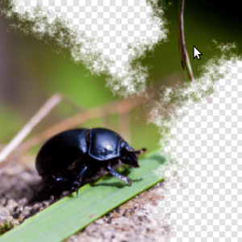

## Example

The following example shows how to apply the effect.

```
import QtQuick
import Qt5Compat.GraphicalEffects

Item {
    width: 300
    height: 300

    Image {
        id: background
        anchors.fill: parent
        source: "images/checker.png"
        smooth: true
        fillMode: Image.Tile
    }

    Image {
        id: bug
        source: "images/bug.jpg"
        sourceSize: Qt.size(parent.width, parent.height)
        smooth: true
        visible: false
    }

    Image {
        id: mask
        source: "images/fog.png"
        sourceSize: Qt.size(parent.width, parent.height)
        smooth: true
        visible: false
    }

    ThresholdMask {
        anchors.fill: bug
        source: bug
        maskSource: mask
        threshold: 0.4
        spread: 0.2
    }
}
```

## Property Documentation

### cached : bool

This property allows the effect output pixels to be cached in order to improve the rendering performance.

Every time the source or effect properties are changed, the pixels in the cache must be updated. Memory consumption is increased, because an extra buffer of memory is required for storing the effect output.

It is recommended to disable the cache when the source or the effect properties are animated.

By default, the property is set to `false`.

### maskSource : variant

This property defines the item that is going to be used as the mask. Mask item gets rendered into an intermediate pixel buffer and the alpha values from the result are used to determine the source item's pixels visibility in the display.

Mask

Effect applied

[figure not shown]

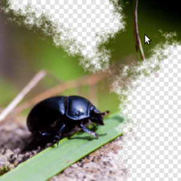

**Note:** It is not supported to let the effect include itself, for instance by setting maskSource to the effect's parent.

### source : variant

This property defines the source item that is going to be masked.

**Note:** It is not supported to let the effect include itself, for instance by setting source to the effect's parent.

### spread : real

This property defines the smoothness of the mask edges near the threshold alpha value. Setting spread to 0.0 uses mask normally with the specified threshold. Setting higher spread values softens the transition from the transparent mask pixels towards opaque mask pixels by adding interpolated values between them.

The value ranges from 0.0 (sharp mask edge) to 1.0 (smooth mask edge). By default, the property is set to `0.0`.

Output examples with different spread values

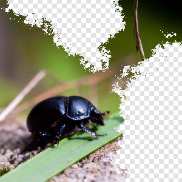

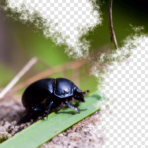

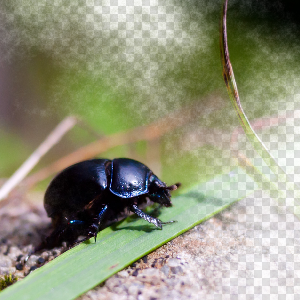

**spread: 0.0**

**spread: 0.2**

**spread: 0.8**

threshold: 0.4

threshold: 0.4

threshold: 0.4

### threshold : real

This property defines a threshold value for the mask pixels. The mask pixels that have an alpha value below this property are used to completely mask away the corresponding pixels from the source item. The mask pixels that have a higher alpha value are used to alphablend the source item to the display.

The value ranges from 0.0 (alpha value 0) to 1.0 (alpha value 255). By default, the property is set to `0.0`.

Output examples with different threshold values

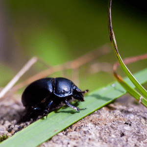

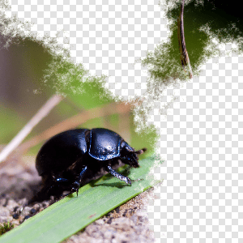

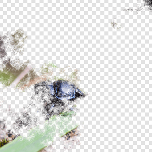

**threshold: 0.0**

**threshold: 0.5**

**threshold: 0.7**

spread: 0.2

spread: 0.2

spread: 0.2

© The Qt Company Ltd  
Licensed under the GNU Free Documentation License, Version 1.3.  
https://doc.qt.io/qt-6.9/qml-qt5compat-graphicaleffects-thresholdmask.html